# Getting Started

M. Juric 2018

This notebook contains most everything that we need to get started. It draws on classes taught by G. Richards (2016), Andy Connolly (http://cadence.lsst.org/introAstroML/), and Karen Leighly (seminar.ouml.org).

## Git and Github

We will use a version control system tool called `git`, and an internet service called [GitHub](http://github.com), that will let you download the notebooks that Zeljko and I put into the class repository before each class.

If you don't have one already, make an account on [GitHub](https://github.com/), where you can create your own repositories. Let's pause and make sure we all have a github account first!

## Git

To get Git for any platform, see: https://git-scm.com/download/.

If you're using a Mac, you'll have `git` installed already. Open a terminal window and run

```
$ which git
```

For example:

```
$ which git
/usr/bin/git

$ git --version
git version 2.14.3 (Apple Git-98)
```

Let's pause and make sure we all have git installed.

## Downloading the class repository

Once Git is installed, make a place where you are going to put the class repository. Perhaps in a git subdirectory if you think that you might use more repositories later (we might even for this class!).

```
$ cd ~
$ mkdir astr-324
$ cd astr-324
```

Now we need to "clone" the class repository into your account

```
$ git clone https://github.com/uw-astr-324-s18/astr-324-s18
```

This will make a subdirectory called `astr-324-s18` in which you will see a file called `Week-01-Thu.ipynb`, which is the file that you are reading now.

Before each class, you will want to update this repository so that you get any new files that we have put there for you. Do that with

```
$ cd ~/astr-324/astr-324-s18
$ git pull
```

# Setting Up Your Computer

Everyone will need to have the proper software environment in order to be able to participate in the course. This can either be on the AST/PHY departmental machines or on your laptop. Which is up to you, but it will be easier to run Jupyter Notebooks off your laptop.

# Software requirements

```
Anaconda Python 3.5+

NumPy version 1.11+: efficient array operations
SciPy version 0.17+: scientific computing tools
matplotlib version 1.5+: plotting and visualization
jupyter version 1.0+: interactive computing (formerly IPython)
Scikit-learn version 0.17+: machine learning
astroML: an astronomical machine learning toolkit
```

## Anaconda Installation

If you don’t already have Anaconda Python 3.X, then go to https://www.continuum.io/downloads and download the installer of your choice (e.g., the graphical OSX installer). Don't worry--it's free.

Open the install package (it's easiest to use the graphical one) and follow the instructions. If asked, install "**for you only**".

Open a **new** terminal window, and make sure your $PATH variable points to the Anaconda installation. You can do this by typing

```
[~]% which python
```

The result should show the path to the newly-installed anaconda folder. If not, you must modify your $PATH variable to point to the anaconda directory as follows:

### If Anaconda isn't in your path

If you use `csh` or `tcsh`, add the following to your `.cshrc` or `.tcshrc` file:

```
set path=(~/anaconda/bin $path)
```

If you use `bash` instead, you’ll have to add the following to your .bashrc file:

```
PATH="$HOME/anaconda/bin:$PATH"
```

Now close that terminal window and open a new one, and then type:

```
$ which python
```

Hopefully all is well now.

### Update your Anaconda distribution

You can occasionally update your anaconda distribution with the following command:

```
$ conda update anaconda
```

Note that `conda` is the package management system that comes with anaconda.

I’m currently running Python 3.6.4 with conda-4.5.0. You don’t have to be doing *exactly* the same, but if you run into problems that I am not having, that would be a good place to start debugging.

Conda will have installed most of the the other software packages listed above. The exceptions are noted below.

## Installing astroML

[astroML](http://www.astroml.org/) is the software library that goes together with [the textbook](http://press.princeton.edu/titles/10159.html). Much of it is a series of wrappers to [scikit-learn](http://scikit-learn.org/), where Jake VanderPlas is one of the main contributors to each. Jake has written an [Intro to AstroML](http://ieeexplore.ieee.org/stamp/stamp.jsp?arnumber=6382200) paper that is worth going through to give you an idea of the sorts of things that we'll be doing in the class.

AstroML requires `scikit-learn`. Let's install that first using **conda**:

```
$ conda install scikit-learn
```

We'll install the bleeding edge version of `astroML` from github, using **pip** (the python package installer):

```
$ pip install git+https://github.com/astroML/astroML
```

and same for the add-on packages:

```
$ pip install git+https://github.com/astroML/astroML_addons
```

## Installing other things

We'll need a few other packages installed as we go along. Here are the ones that I remembered to write down. You can either install them now, or you can do it later (when you get an error message!).

```
$ conda install -c astropy astroquery
```

```
$ pip install corner
```

## Python

The course requirements were setup up to ensure that you have at least *some* (extended) experience with Python. If you taken ASTR 300, this should be the case. However, if you need a refresher, a good place to start is **Appendix A** (more specifically A3) in the textbook.

I also recommend the [codecademy](https://www.codecademy.com/) course on Python. It is free and does a good job of walking you through things that you need to learn.

You might also be interested in [A Student’s Guide to Python for Physical Modeling](http://press.princeton.edu/titles/10644.html): Chapters 1-3 provide a good introduction to Python before getting into the "physical modeling" part. It encourages the use of **spyder**, which is a matlab-like interactive interface for Python (I've never used it, personally).

And, of course, you can google 'python tutorial' (or some such) and find a plethora of things that you may or may not like better.

## Jupyter notebooks

In this class, we will use Python almost exclusively through Jupyter Notebooks. To start the notebook app, run:

```
$ jupyter notebook
```

This will pop up a web page in your default browser and show the Dashboard where you can navigate to a particular notebook or open a new one. You can also open a notebook directly with

```
$ jupyter notebook Week-01-Thu.ipynb
```

If you are creating a new notebook, click on 'new' at the top-right of the page and select 'python'.

## Working with jupyter notebooks and IPython

Notebooks have two primary cell types: 'Markdown' and 'Code'. The Markdown cells are basically just for you to read. The Code cells are meant to be executed (perhaps after you have filled in some blanks).

To execute a cell in the notebook, type '**shift-return**'. If you see a * in the square bracket to the left of the cell or a 'Busy' in the tab title, it means the command is in the process of running, and you need to wait for it to finish.

The notebook is autosaved, so that when you return to a notebook, everything is the same as you left it. If you want to reset it, you can do “revert to checkpoint”. If you save it yourself, you will create a checkpoint, and the original version will be unavailable.

Here are some useful IPython commands to get you started (# followed by text indicates a comment and not what you type)!

```
In [ ]: ?          # basic help function.  Pops open a sub-frame at the bottom of page.
                     Close with "x".

In [ ]: %quickref  # Pops open a quick reference card

In [ ]: !          # spawning out to the operating system;
                     e.g files=!ls will fill the variable files
                     with a list of files in your directory.
```

IPython also contains a number of [“magic” commands](https://ipython.org/ipython-doc/dev/interactive/magics.html). Two examples are

```
In [ ]: %matplotlib inline  # makes plots within the web browser instead of popping up a new window

In [ ]: %whos               # lists the vectors, etc. that you have defined.
```

IPython also has lots of [keyboard shortcuts](https://ipython.org/ipython-doc/1/interactive/notebook.html#keyboard-shortcuts) – the main one is shift-enter to run a cell.

## AstroML Example

Let's download and run one of the astroML examples inside the Jupyter notebook.

```python
! curl -O https://raw.githubusercontent.com/astroML/astroML/master/examples/datasets/plot_SDSS_SSPP.py
```

```
  % Total    % Received % Xferd  Average Speed   Time    Time     Time  Current
                                 Dload  Upload   Total   Spent    Left  Speed
100  3049  100  3049    0     0   3049      0  0:00:01 --:--:--  0:00:01 60980
```

This will run the downloaded file

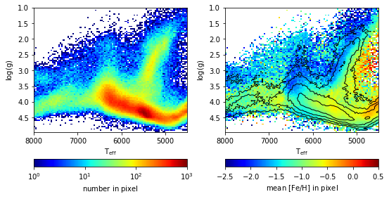

```python
%run ./plot_SDSS_SSPP.py
```

## NumPy

NumPy is short for Numerical Python. It is the foundational package for scientific computing in Python. It is a library which will allow us to work with data structures called **arrays** that are more efficient for storing and manipulating data than other Python data structures (or C++ for that matter).

For example, cut and paste this into a new cell, then type shift-enter to run it:

```python
import numpy as np
xlist = [1,2,3,4,5,6,7,8,9,10,11,12,13,14,15,16,17,18,19,20]
xarray = np.array(xlist)
twice_xarray = 2*xarray
print(twice_xarray)
```

```
[ 2  4  6  8 10 12 14 16 18 20 22 24 26 28 30 32 34 36 38 40]
```

This is far better than creating a `for` loop over the entries in `xlist` or even something fancier like a "list comprehension"

```python
xlist = [1,2,3,4,5,6,7,8,9,10,11,12,13,14,15,16,17,18,19,20]
twice_xlist = [2*x for x in xlist]
print(twice_xlist)
```

```
[2, 4, 6, 8, 10, 12, 14, 16, 18, 20, 22, 24, 26, 28, 30, 32, 34, 36, 38, 40]
```

To load the Numpy library type:

```
import numpy as np
```

In fact, just plan on starting **every** new series of code cells with this!

The basic unit for numpy is an [ndarray](https://docs.scipy.org/doc/numpy/reference/arrays.ndarray.html). See the link for examples of how to define, index, slice, etc. the array.

There are quite a few **methods** associated with arrays. Some useful ones include:

[output not shown]

More methods for multidimensional arrays:

| Method | Property |
| --- | --- |
| d=c[0,:] | grabs the first (0th) row of c. |
| d=c[1,:] | grabs the second (1st) row of c. |
| d=c[:,0] | grabs the first column of c. |
| c.dtype | data type |
| c.size | total number of elements |
| c.ndim | number of dimensions |
| c.shape | shape or dimensionality |
| c.nbytes | memory used (bytes) |
| c.min() | gives the minimum of c |
| c.max() | gives the maximum of c |
| c.sum() | sum of all elements |
| c.mean() | mean of all elements |
| c.std() | standard deviation of all elements |
| c.sum(axis=0) | will present sum along the 0th axis (column direction). The result will have reduced dimensionality |

You can also operate with arrays, for example, adding them together, multiplying them, multiplying or adding a constant. There are, however, "broadcasting" rules so that you need to make sure you know what you are doing when dealing with arrays of different sizes.

## SciPy

[SciPy](http://docs.scipy.org/doc/scipy/reference/) is an "open-source software for mathematics, science, and engineering". We 'import' it the same way that we import numpy:

```
import scipy
```

SciPy is a suite of tools for data analysis including integration, statistical functions, interpolation. It is built on top of Numpy. Where Numpy is intended for array *manipulation*, Scipy is intended for *analysis*. This is where many useful tools will be. It may be worth looking at the users guide to get an idea of the kinds of functions are available. N.B. For some packages you need to import more than just the main scipy package. So, for example to see what is available in the scipy.integrate package, do the following:

```
import scipy.integrate
scipy.integrate?
```

You can also make use of TAB completetion to see what is available

```
scipy.integrate.[TAB]
```

The catch is that, since we are using notebooks, you need to have *imported* FIRST, because otherwise the computer doesn't know what you are asking about yet.

```python
# Example
import scipy.integrate
scipy.integrate?
```

## Matplotlib

It is generally useful to be able to visualize your data. We will do that using the [matplotlib](http://matplotlib.org/) library. Most of you should be familiar with it already, but we will likely be making some plots that are more complex than you are used to. One nice resource is this [thumbnail gallery](http://matplotlib.org/gallery.html) which you can use to figure out how to make a new plot.

Let's make sure that everything is working by making a simple plot

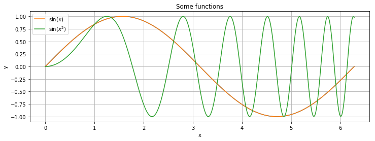

```python
# magic command to make the figure pop up below instead of in a new window
%matplotlib inline

# invoke pyplot in matplotlib, give it an alias
import matplotlib.pyplot as plt
import numpy as np

x = np.linspace(0, 2*np.pi, 300)
y = np.sin(x)
plt.figure(figsize=(12,4))
plt.plot(x, y)
y2 = np.sin(x**2)
plt.plot(x, y, label=r'$\sin(x)$')
plt.plot(x, y2, label=r'$\sin(x^2)$')
plt.title('Some functions')
plt.xlabel('x')
plt.ylabel('y')
plt.grid()
plt.legend();
```

You can change both the [marker/line styles](http://matplotlib.org/examples/lines_bars_and_markers/) and [colors](http://matplotlib.org/api/colors_api.html). I highly recommend the use of the colors in the [palettable library](https://jiffyclub.github.io/palettable/). You can see the colors at http://colorbrewer2.org/.

Try making some changes to the code above and see what happens.

## Scikit-learn

The [Scikit-learn library](http://scikit-learn.org/) forms the core of computing tools that we will use for this class. The "scikit"s are add-ons to **scipy**. Scikit-learn is the add-on for machine learning.

It probably needs its own introductory tutorial as both the input and output may not be quite what you would have expected. You might want to spend some time going through their quick start guide, user's guide and tutorials here: http://scikit-learn.org/stable/documentation.html.

Ironically, Scikit-learn is **NOT** really intended for Big Data (despite the title of the course). We will be using it to learn the basics of machine learning and big data analysis. However, we'll see that if you want to do any real Big Data analysis, you'll need other tools.

## Intro to Everything

Lastly, here is a tutorial on the whole scientific Python "ecosystem": [www.scipy-lectures.org](http://www.scipy-lectures.org/)

## Let's practice some git!

1. create a new repository on github, with a README file. Name it `astr324-test`.
2. clone it using:

   ```
   git clone https://github.com/YOURNAME/astr324-test
   ```

3. start Jupyter in the cloned directory

   ```
   cd astr324-test
   jupyter notebook &
   ```

4. create a new Python 2 notebook. Name it `hello.ipynb`, and add a cell with the following piece of code:

   ```
   print "Hello World!"
   ```

5. make TextEdit your default editor (otherwise git will start `vi` any time in needs you to edit something). Run the following in the terminal window:

   ```
   echo "export EDITOR=/Applications/TextEdit.app/Contents/MacOS/TextEdit" >> ~/.bashrc
   ```

6. add the notebook to your git repository and commit by running (in the terminal window) the following:

   ```
   git add hello.ipynb
   git commit
   ```

7. see what happened:

   ```
   git log
   ```

8. make another change in the Jupyter notebook. For example, add another cell with the following:

   ```
   x = 2+2
   x
   ```

9. see what happened

   ```
   git status
   ```

10. commit changed files

    ```
    git commit -a
    ```

11. "push" the changes to github

    ```
    git push
    ```

12. go browse the result on github

# Summary

At this point, all of you should have:

- A `GitHub` account and a basic understanding of `git`
- Installed the Anaconda Python Distribution with Python 3
- Installed AstroML
- The ability to create and run Jupyter notebooks

Now we're ready to do some astro-statistics!